# Morphological characterization of Peruvian highland maize races using multivariate analysis

Author

Flavio Lozano-Isla; Pedro M. Rodriguez-Grados; Ricardo Sevilla; Alexander Grobman; Rodomiro Orti and Carlos I. Arbizu

# 1 Project Setup

```r
library(factoextra)
library(corrplot)
source('https://inkaverse.com/setup.r')
```

```
Project directory:  C:/Users/LENOVO/git/flint_maize
CPU cores detected:  32
CPU cores in use:  25
```

# 2 Research Objective

> https://docs.google.com/spreadsheets/d/1Us3b4buA-tXxltZd1kd970NttFA4k_apQvLdQ8BXXTw/edit?gid=543463494#gid=543463494

# 3 Data import

- Data morfológica curada de los maíces amiláceos Peruanos de Grobman et al (1961).
- Select variables with more than 80% of data.

```r
url <- "https://docs.google.com/spreadsheets/d/1Us3b4buA-tXxltZd1kd970NttFA4k_apQvLdQ8BXXTw/edit?gid=37859623#gid=37859623"

gs <- url %>%
  as_sheets_id()

rawdata <- gs %>%
  range_read("STable1")
rawdata %>% dim()
## [1]  43 130
rawdata %>% str()
## tibble [43 × 130] (S3: tbl_df/tbl/data.frame)
##  $ Race                                          : chr [1:43] "Confite Morocho" "Confite Puntiagudo" "Kculli" "Confite Puneño" ...
##  $ Group                                         : chr [1:43] "Primitive" "Primitive" "Primitive" "Primitive" ...
##  $ Period                                        : chr [1:43] "Inca" "Mochica" "Mochica" NA ...
##  $ range_of_altitude_(m)                         : chr [1:43] "2500-3000" "2500--3500" "2300--3300" "3600--3900" ...
##  $ plant_color                                   : chr [1:43] "DSRSR" "DSR" "PSR" "SRP" ...
##  $ plant_pubescence                              :List of 43
##   ..$ : chr "0.7 M"
##   ..$ : chr "0.7 M"
##   ..$ : num 0
##   ..$ : chr "0.5 M"
##   ..$ : chr "1.3 M"
##   ..$ : num 0.5
##   ..$ : num 0.4
##   ..$ : chr "1.0 M"
##   ..$ : num 0
##   ..$ : chr "0.5 M"
##   ..$ : chr "0.5 M"
##   ..$ : chr "2.0 S"
##   ..$ : chr "2.0 M"
##   ..$ : chr "1.0 M"
##   ..$ : chr "1.0 M"
##   ..$ : chr "1.3 M"
##   ..$ : num 0.5
##   ..$ : num 0
##   ..$ : chr "1.3 M"
##   ..$ : chr "1.1 M"
##   ..$ : chr "0.8 M"
##   ..$ : num 0.4
##   ..$ : num 0.5
##   ..$ : num 0.5
##   ..$ : chr "1.0 AM"
##   ..$ : num 1.5
##   ..$ : chr "1.5 MS"
##   ..$ : num 0.5
##   ..$ : chr "1.0 MS"
##   ..$ : chr "1.0 M"
##   ..$ : chr "0.7 S"
##   ..$ : chr "2.0 MS"
##   ..$ : num 0
##   ..$ : chr "1.0 S"
##   ..$ : chr "1.0 M"
##   ..$ : chr "1.5 M"
##   ..$ : chr "1.0 M"
##   ..$ : chr "1.0 MS"
##   ..$ : chr "1.0 S"
##   ..$ : num 0.3
##   ..$ : num 0
##   ..$ : chr "As"
##   ..$ : chr "1.0"
##  $ plant_days_to_flowering                       : num [1:43] 116 125 137 91 NA 138 144 140 144 143 ...
##  $ plant_height                                  : num [1:43] 127 116 92 56 136 118 200 136 124 154 ...
##  $ plant_ears_height                             : num [1:43] 56 49 29 12 83 87 76 53 38 91 ...
##  $ plant_ear_position_(node)                     : num [1:43] 3 6 NA 2 NA 8 8 NA 4 6 ...
##  $ plant_stalk_Diameter_(mm)                     : num [1:43] 16 16.7 19 10 19.4 20.1 19.5 24 17 20.5 ...
##  $ plant_prop_roots                              : num [1:43] 0.05 0.01 0 0 0.2 0.28 0.07 0.15 0 0.25 ...
##  $ plant_tillers                                 : num [1:43] 0 0 0 0 NA 0 0.012 0 0 0 ...
##  $ plant_seeding_color_index                     : num [1:43] 4.5 4.25 3 3 NA 2.86 4.28 3.28 4.5 3.92 ...
##  $ ear_length_(cm)                               : num [1:43] 7.5 5.8 4 NA NA NA NA NA NA NA ...
##  $ ear_width_(cm)                                : num [1:43] 1.9 3.8 1.9 NA NA NA NA NA NA NA ...
##  $ ear_rows_of_kernels                           : num [1:43] 8 NA NA NA NA NA NA NA NA NA ...
##  $ ear_No_of_Kernels_in_row                      : num [1:43] 17 NA 10 NA NA NA NA NA NA NA ...
##  $ ear_kernel_width_(mm)                         : num [1:43] 6 NA NA NA NA NA NA NA NA NA ...
##  $ ear_kernel_thickness_(mm)                     : num [1:43] 4 NA NA NA NA NA NA NA NA NA ...
##  $ ear_imbrication                               : num [1:43] 1.5 2.5 0 NA NA NA NA NA NA NA ...
##  $ leaf_No_of_leaves                             : num [1:43] 11.9 8.7 9.5 5.8 12.5 10.7 10.4 10.4 9.3 9.6 ...
##  $ leaf_No_of_leaves_above_ear                   : num [1:43] 5.6 4.2 5.3 4.6 6.2 5.3 5.1 5.4 4.5 4.7 ...
##  $ leaf_length_(cm)                              : num [1:43] 53.4 56.2 58 52.3 73.7 61.6 72 66.6 36.2 59 ...
##  $ leaf_width_(cm)                               : num [1:43] 6.3 6.5 7.4 5.7 7.7 7.7 8.2 6.9 6.9 8.7 ...
##  $ leaf_area_(cm2)                               : num [1:43] 2674 2356 4707 863 NA ...
##  $ leaf_venation_index                           : num [1:43] 3.8 3.69 3.31 2.46 2.92 3.2 3.33 3.1 3.46 3.58 ...
##  $ leaf_pattern_index_quadrant_I                 : num [1:43] 9.3 0 0 6.7 NA 0 0 18.9 6.7 0 ...
##  $ leaf_pattern_index_quadrant_II                : num [1:43] 42.4 31 85 0 NA 94.4 42.5 32.2 89.1 100 ...
##  $ leaf_pattern_index_quadrant_III               : num [1:43] 16.4 31.6 0 93.2 NA 0 18.3 24.2 0 0 ...
##  $ leaf_pattern_index_quadrant_IV                : num [1:43] 31.9 37.7 15 0 NA 5.6 39.2 24.6 4.2 0 ...
##  $ leaf_susceptibility_rust                      : num [1:43] 2.7 1.8 1.3 2.7 1.1 3 2.1 2.5 2 2.2 ...
##  $ leaf_susceptibility_helminthosporium          : num [1:43] 1.5 2.9 2.5 2.2 1.8 2.5 3.5 2.1 1.7 2.1 ...
##  $ tassel_length_of_peduncle_(cm)                : num [1:43] 27.2 20 19.6 22.4 14 19.5 18 18.2 25.5 21 ...
##  $ tassel_tassel_length_(cm)                     : num [1:43] 28.7 24.7 27.2 18.7 NA 19.1 28.5 27.7 33 24.8 ...
##  $ tassel_length_of_terminal_spike_(cm)          : num [1:43] 19.3 15.6 18.3 14.3 NA 10.8 13.9 14.1 21 17 ...
##  $ tassel_length_of_branching_space_(cm)         : num [1:43] 9.4 9.1 8.8 4.4 NA 8.2 14.6 13.6 12 7.8 ...
##  $ tassel_percentage_of_branching_space          : num [1:43] 32.7 36.8 22.1 23.5 NA 43.5 51.2 49.1 36.4 31.5 ...
##  $ tassel_length_of_upper_branch_(cm)            : num [1:43] 12.4 10.5 11.5 9.2 NA 8.6 10.6 9.4 14 10.6 ...
##  $ tassel_length_(cm)_largest_branch             : num [1:43] 19.7 17.2 16.3 12.2 NA 13.3 18.4 19.8 18.8 14.9 ...
##  $ tassel_number_of_secondaries_on_largest_branch: num [1:43] 1.5 0.8 1.3 0.1 NA 0.9 1.2 2 0.5 0.5 ...
##  $ tassel_number_of_tertiaries_on_largest_branch : num [1:43] 0.1 0 0 0 NA 0 0 0 0 0 ...
##  $ tassel_number_of_primary_branches             : num [1:43] 10.7 9 10.3 5.9 NA 14.9 18 15.2 11.5 9.9 ...
##  $ tassel_number_of_secondary_branches           : num [1:43] 4.2 2.8 2.3 0.1 NA 3.3 4.5 9.5 5.5 2 ...
##  $ tassel_number_of_tertiary_branches            : num [1:43] 0.1 0 0 0 NA 0 0 0 0 0 ...
##  $ tassel_condensation_index                     : num [1:43] 1 1.02 1 1 NA 1.01 1 1.02 1.03 1 ...
##  $ earexternal_length_(cm)                       : num [1:43] 6.78 8.86 9.23 6.58 7.22 ...
##  $ earexternal_width_(cm)                        : num [1:43] 2.32 3.24 4.71 3.45 2.5 4.93 4.63 5.16 5.84 4.25 ...
##  $ ear_diameter_tip_(cm)                         : num [1:43] 2.17 2.87 3.38 3.8 2.01 3.6 5.28 3.5 3.64 3.05 ...
##  $ ear_diameter_base_(cm)                        : num [1:43] 2.69 3.34 4.71 4.46 2.7 4.2 5.86 4.18 4.67 3.73 ...
##  $ ear_row_number                                : num [1:43] 10.7 15.1 12 16 NA ...
##  $ shank_length_(cm)                             : num [1:43] 5.17 7.7 6.14 NA NA 4.82 6.46 6.75 5.25 4.3 ...
##  $ shank_diameter_(cm)                           : num [1:43] 0.42 NA 0.88 0.9 NA 1 0.73 1.03 1.13 0.93 ...
##  $ shank_number_of_internodes                    : num [1:43] 4.8 4.9 5.5 NA NA 4.7 5.3 4.5 4.32 4.7 ...
##  $ kernel_length_(mm)                            : num [1:43] 7.34 8.26 13.78 9.19 6.2 ...
##  $ kernel_width_(mm)                             : num [1:43] 5.87 5.55 10.27 6.74 5.3 ...
##  $ kernel_thickness_(mm)                         : num [1:43] 4.55 4.33 6.01 4.98 3.7 5.3 4.3 6 5.14 5.65 ...
##  $ kernel_denting                                : num [1:43] 1 0 0 0.3 0.4 0 3 0.16 NA 0 ...
##  $ kernel_striation                              : num [1:43] 1 0 1 0.9 1.8 0 0 0.5 NA 0.1 ...
##  $ kernel_hardness                               : num [1:43] 2.66 1.97 2.6 2.12 NA 2.6 2.27 1.54 NA 1.9 ...
##  $ pericob_APrrPlrch_pericarpCob_cherrypurple    : num [1:43] NA NA 47.8 18 NA 2.6 NA 2 NA NA ...
##  $ pericob_APrrrch_cherryRed                     : num [1:43] NA NA 1.5 NA NA NA NA NA NA NA ...
##  $ pericob_Aprr_redred                           : num [1:43] NA NA 10.1 2.6 NA 11 2.6 7.1 1.8 NA ...
##  $ pericob_APrrPl_redpurple                      : num [1:43] NA NA NA NA NA 1.5 NA NA NA NA ...
##  $ pericob_APrw_redwhite                         : num [1:43] NA NA NA NA NA NA NA 2 NA NA ...
##  $ pericob_APwr_colorlessred                     : num [1:43] NA 5.3 10.1 2.6 NA 4.9 9.3 9.2 17.8 8 ...
##  $ pericob_APcr_red_white_capred                 : num [1:43] NA NA NA 2.6 NA 5.1 NA 6.1 1.8 NA ...
##  $ pericob_APcrPl_red_white_cappurple            : num [1:43] NA NA NA NA NA 1 NA 2.5 1.8 0.76 ...
##  $ pericob_APcw_red_white_capwhite               : num [1:43] NA NA NA 2.6 NA 3.1 NA 4.6 1.8 NA ...
##  $ pericob_APuv_variegaled_redmosaic_red         : num [1:43] NA 3.1 3 10.3 NA 2 5.3 7.7 5.4 NA ...
##  $ pericob_APmo_mosaic_redmosaic_red             : num [1:43] NA NA NA 2.6 NA 1.5 5.3 1 1.8 NA ...
##  $ pericob_ap_Prr_brown_redred                   : num [1:43] NA NA NA NA NA 0.3 NA NA NA NA ...
##  $ pericob_ap_Prr_brown_redbrown_red             : num [1:43] NA NA 1.5 2.6 NA 5.6 NA 2 1.8 NA ...
##  $ pericob_ap_PrPl_brown_redpurple               : num [1:43] NA NA NA NA NA 0.3 NA NA NA 0.76 ...
##  $ pericob_ap_Prw_brown_redwhite                 : num [1:43] NA NA NA NA NA 0.3 NA NA NA NA ...
##  $ pericob_Ab_Prr_brownbrown                     : num [1:43] NA NA NA NA NA 10.1 NA 8.2 7.1 NA ...
##  $ pericob_Ab,Prr_light_brownLight_brown         : num [1:43] NA 4.6 1.5 7.7 NA 13.6 13.3 6.6 1.8 NA ...
##  $ pericob_Ab_Prw_light_brownwhite               : num [1:43] NA NA NA NA NA 3.1 2.6 0.5 1.8 NA ...
##  $ pericob_Ab_Prw_brownwhite                     : num [1:43] NA 3.1 NA NA NA 1.8 NA 0.5 NA NA ...
##  $ pericob_Ab_Pwr_colorlessbrown                 : num [1:43] NA NA NA NA NA 0.5 NA NA NA NA ...
##  $ pericob_Ab_Pcw_brown_white_capwhite           : num [1:43] NA NA NA NA NA 0.3 NA 0.5 NA NA ...
##  $ pericob_Ab_Pcr_brown_white_capbrown           : num [1:43] NA NA 3 NA NA 2 1.3 2 NA NA ...
##  $ pericob_Ab_Pvv_variegated_brownbrown          : num [1:43] NA NA NA NA NA 1.8 NA 0.5 NA NA ...
##  $ pericob_Ab_Pmo_mosaic_brownmosaic_brown       : num [1:43] NA NA NA NA NA NA NA 0.5 1.8 NA ...
##  $ pericob_Ab_Pmo_mosaic_brownwhite              : num [1:43] NA NA NA NA NA 1 NA NA NA NA ...
##  $ pericob_Ab_P_splashed_brownbrown              : num [1:43] NA NA NA NA NA 0.8 NA NA NA NA ...
##  $ pericob_ColorlessPurple                       : num [1:43] NA NA NA NA NA 0.8 NA NA NA NA ...
##  $ pericob_colorlesswhite                        : num [1:43] 100 84 18.8 48.7 NA 18.7 58.6 34.7 53.5 68.7 ...
##  $ pericob_light_brownred                        : num [1:43] NA NA NA NA NA 0.3 NA 1.5 NA NA ...
##  $ pericob_Ab_PvvPww_variegated_brownwhite       : num [1:43] NA NA NA NA NA 0.3 NA NA NA NA ...
##  $ pericob_APow_orangewhite                      : num [1:43] NA NA NA NA NA NA NA NA NA NA ...
##  $ pericob_APor_orangered                        : num [1:43] NA NA NA NA NA NA NA NA NA NA ...
##  $ pericob_APorPl_orangeopurple                  : num [1:43] NA NA NA NA NA NA NA NA NA NA ...
##  $ earint_ear_diameter_(mm)                      : num [1:43] 26.3 33.5 46.9 44.5 NA 42 58 42.6 43.3 37.3 ...
##  $ earint_cob_diameter_(mm)                      : num [1:43] 12 21.6 21.3 20 14.3 21 29.2 23 29.4 22.4 ...
##  $ earint_rachis_diameter_(mm)                   : num [1:43] 5.2 12.6 15.2 13 7.8 11.4 18.2 13.2 20.1 13.2 ...
##  $ earint_pith_diameter_(mm)                     : num [1:43] 2 6.5 5.7 4.7 3.8 5.3 9.2 5.2 10.3 6.4 ...
##  $ earint_rachilla_length_(mm)                   : num [1:43] 1.4 1.7 0.8 4.2 2.4 2.3 3.4 1.6 3.8 1 ...
##  $ earintcup_length_(mm)                         : num [1:43] 3.1 1.6 1.4 1.6 1.3 2.1 1.1 1.7 1.2 2.2 ...
##   [list output truncated]
```

```r
fb <- rawdata %>%
  dplyr::select(where(~ mean(!is.na(.x)) >= 0.8)) %>%
  rename_with(~ tolower(gsub(" ", "_", .x))) %>%
  rename_with(~ tolower(gsub("\\(|\\)", "", .x))) %>%
  mutate(across(1:plant_pubescence, ~ as.character(.))) %>%
  mutate(across(1:plant_pubescence, ~ as.factor(.)))
fb %>% dim()
## [1] 43 73

cat("Variables with more 80% of data: ", ncol(fb))
## Variables with more 80% of data:  73

fb %>% str()
## tibble [43 × 73] (S3: tbl_df/tbl/data.frame)
##  $ race                                          : Factor w/ 43 levels "Alazan","Aleman",..: 11 13 24 12 18 22 9 19 32 28 ...
##  $ group                                         : Factor w/ 6 levels "Anciently","Imperfectly",..: 6 6 6 6 6 1 1 1 1 1 ...
##  $ range_of_altitude_m                           : Factor w/ 32 levels "10--2000","10--500",..: 23 21 14 29 NA 22 15 25 25 10 ...
##  $ plant_color                                   : Factor w/ 10 levels "DSR","DSRG","DSRSR",..: 3 1 6 10 4 1 9 9 9 3 ...
##  $ plant_pubescence                              : Factor w/ 22 levels "0","0.3","0.4",..: 6 6 1 5 15 4 3 11 1 5 ...
##  $ plant_days_to_flowering                       : num [1:43] 116 125 137 91 NA 138 144 140 144 143 ...
##  $ plant_height                                  : num [1:43] 127 116 92 56 136 118 200 136 124 154 ...
##  $ plant_ears_height                             : num [1:43] 56 49 29 12 83 87 76 53 38 91 ...
##  $ plant_stalk_diameter_mm                       : num [1:43] 16 16.7 19 10 19.4 20.1 19.5 24 17 20.5 ...
##  $ plant_prop_roots                              : num [1:43] 0.05 0.01 0 0 0.2 0.28 0.07 0.15 0 0.25 ...
##  $ plant_tillers                                 : num [1:43] 0 0 0 0 NA 0 0.012 0 0 0 ...
##  $ plant_seeding_color_index                     : num [1:43] 4.5 4.25 3 3 NA 2.86 4.28 3.28 4.5 3.92 ...
##  $ leaf_no_of_leaves                             : num [1:43] 11.9 8.7 9.5 5.8 12.5 10.7 10.4 10.4 9.3 9.6 ...
##  $ leaf_no_of_leaves_above_ear                   : num [1:43] 5.6 4.2 5.3 4.6 6.2 5.3 5.1 5.4 4.5 4.7 ...
##  $ leaf_length_cm                                : num [1:43] 53.4 56.2 58 52.3 73.7 61.6 72 66.6 36.2 59 ...
##  $ leaf_width_cm                                 : num [1:43] 6.3 6.5 7.4 5.7 7.7 7.7 8.2 6.9 6.9 8.7 ...
##  $ leaf_area_cm2                                 : num [1:43] 2674 2356 4707 863 NA ...
##  $ leaf_venation_index                           : num [1:43] 3.8 3.69 3.31 2.46 2.92 3.2 3.33 3.1 3.46 3.58 ...
##  $ leaf_pattern_index_quadrant_i                 : num [1:43] 9.3 0 0 6.7 NA 0 0 18.9 6.7 0 ...
##  $ leaf_pattern_index_quadrant_ii                : num [1:43] 42.4 31 85 0 NA 94.4 42.5 32.2 89.1 100 ...
##  $ leaf_pattern_index_quadrant_iii               : num [1:43] 16.4 31.6 0 93.2 NA 0 18.3 24.2 0 0 ...
##  $ leaf_pattern_index_quadrant_iv                : num [1:43] 31.9 37.7 15 0 NA 5.6 39.2 24.6 4.2 0 ...
##  $ leaf_susceptibility_rust                      : num [1:43] 2.7 1.8 1.3 2.7 1.1 3 2.1 2.5 2 2.2 ...
##  $ leaf_susceptibility_helminthosporium          : num [1:43] 1.5 2.9 2.5 2.2 1.8 2.5 3.5 2.1 1.7 2.1 ...
##  $ tassel_length_of_peduncle_cm                  : num [1:43] 27.2 20 19.6 22.4 14 19.5 18 18.2 25.5 21 ...
##  $ tassel_tassel_length_cm                       : num [1:43] 28.7 24.7 27.2 18.7 NA 19.1 28.5 27.7 33 24.8 ...
##  $ tassel_length_of_terminal_spike_cm            : num [1:43] 19.3 15.6 18.3 14.3 NA 10.8 13.9 14.1 21 17 ...
##  $ tassel_length_of_branching_space_cm           : num [1:43] 9.4 9.1 8.8 4.4 NA 8.2 14.6 13.6 12 7.8 ...
##  $ tassel_percentage_of_branching_space          : num [1:43] 32.7 36.8 22.1 23.5 NA 43.5 51.2 49.1 36.4 31.5 ...
##  $ tassel_length_of_upper_branch_cm              : num [1:43] 12.4 10.5 11.5 9.2 NA 8.6 10.6 9.4 14 10.6 ...
##  $ tassel_length_cm_largest_branch               : num [1:43] 19.7 17.2 16.3 12.2 NA 13.3 18.4 19.8 18.8 14.9 ...
##  $ tassel_number_of_secondaries_on_largest_branch: num [1:43] 1.5 0.8 1.3 0.1 NA 0.9 1.2 2 0.5 0.5 ...
##  $ tassel_number_of_tertiaries_on_largest_branch : num [1:43] 0.1 0 0 0 NA 0 0 0 0 0 ...
##  $ tassel_number_of_primary_branches             : num [1:43] 10.7 9 10.3 5.9 NA 14.9 18 15.2 11.5 9.9 ...
##  $ tassel_number_of_secondary_branches           : num [1:43] 4.2 2.8 2.3 0.1 NA 3.3 4.5 9.5 5.5 2 ...
##  $ tassel_number_of_tertiary_branches            : num [1:43] 0.1 0 0 0 NA 0 0 0 0 0 ...
##  $ tassel_condensation_index                     : num [1:43] 1 1.02 1 1 NA 1.01 1 1.02 1.03 1 ...
##  $ earexternal_length_cm                         : num [1:43] 6.78 8.86 9.23 6.58 7.22 ...
##  $ earexternal_width_cm                          : num [1:43] 2.32 3.24 4.71 3.45 2.5 4.93 4.63 5.16 5.84 4.25 ...
##  $ ear_diameter_tip_cm                           : num [1:43] 2.17 2.87 3.38 3.8 2.01 3.6 5.28 3.5 3.64 3.05 ...
##  $ ear_diameter_base_cm                          : num [1:43] 2.69 3.34 4.71 4.46 2.7 4.2 5.86 4.18 4.67 3.73 ...
##  $ ear_row_number                                : num [1:43] 10.7 15.1 12 16 NA ...
##  $ shank_length_cm                               : num [1:43] 5.17 7.7 6.14 NA NA 4.82 6.46 6.75 5.25 4.3 ...
##  $ shank_diameter_cm                             : num [1:43] 0.42 NA 0.88 0.9 NA 1 0.73 1.03 1.13 0.93 ...
##  $ shank_number_of_internodes                    : num [1:43] 4.8 4.9 5.5 NA NA 4.7 5.3 4.5 4.32 4.7 ...
##  $ kernel_length_mm                              : num [1:43] 7.34 8.26 13.78 9.19 6.2 ...
##  $ kernel_width_mm                               : num [1:43] 5.87 5.55 10.27 6.74 5.3 ...
##  $ kernel_thickness_mm                           : num [1:43] 4.55 4.33 6.01 4.98 3.7 5.3 4.3 6 5.14 5.65 ...
##  $ kernel_denting                                : num [1:43] 1 0 0 0.3 0.4 0 3 0.16 NA 0 ...
##  $ kernel_striation                              : num [1:43] 1 0 1 0.9 1.8 0 0 0.5 NA 0.1 ...
##  $ kernel_hardness                               : num [1:43] 2.66 1.97 2.6 2.12 NA 2.6 2.27 1.54 NA 1.9 ...
##  $ pericob_colorlesswhite                        : num [1:43] 100 84 18.8 48.7 NA 18.7 58.6 34.7 53.5 68.7 ...
##  $ earint_ear_diameter_mm                        : num [1:43] 26.3 33.5 46.9 44.5 NA 42 58 42.6 43.3 37.3 ...
##  $ earint_cob_diameter_mm                        : num [1:43] 12 21.6 21.3 20 14.3 21 29.2 23 29.4 22.4 ...
##  $ earint_rachis_diameter_mm                     : num [1:43] 5.2 12.6 15.2 13 7.8 11.4 18.2 13.2 20.1 13.2 ...
##  $ earint_pith_diameter_mm                       : num [1:43] 2 6.5 5.7 4.7 3.8 5.3 9.2 5.2 10.3 6.4 ...
##  $ earint_rachilla_length_mm                     : num [1:43] 1.4 1.7 0.8 4.2 2.4 2.3 3.4 1.6 3.8 1 ...
##  $ earintcup_length_mm                           : num [1:43] 3.1 1.6 1.4 1.6 1.3 2.1 1.1 1.7 1.2 2.2 ...
##  $ earintcup_width_mm                            : num [1:43] 2.9 5.1 8.1 7.4 3.7 5.3 7.1 6.9 7.5 8.2 ...
##  $ earintcup_depth_mm                            : num [1:43] 1.4 1.4 2.4 1.9 1 1.6 1.4 1.4 1.2 2.4 ...
##  $ earintcup_pubescence                          : num [1:43] 1.15 1.5 1.1 2.05 1.9 2.2 1 1.3 1.52 1.5 ...
##  $ earint_height_rachis_flaps                    : num [1:43] 1.6 1.5 1.66 1.3 1.3 0.95 2 1.3 1.56 1.65 ...
##  $ earintcup_rachis_induration                   : num [1:43] 2.9 3.3 3 3.35 3.1 3.2 3.3 2.7 3.18 3.12 ...
##  $ earintcupindex_cob_rachis                     : num [1:43] 2.3 1.71 1.4 1.54 1.83 1.84 1.6 1.74 1.46 1.69 ...
##  $ earintcupindex_glume_kernel                   : num [1:43] 0.37 0.52 0.2 0.3 0.52 0.37 0.33 0.37 0.31 0.42 ...
##  $ earintcupindex_rachilla_kernel                : num [1:43] 0.16 0.19 0.05 0.36 0.38 0.18 0.21 0.12 0.25 0.09 ...
##  $ earintlowglume_length_mm                      : num [1:43] 4.2 4.8 3.1 5.2 3.5 5.1 5.4 5.7 5.8 6.3 ...
##  $ earintlowglume_pubesence                      : num [1:43] 1.6 1.53 1.6 1.95 1.7 2.1 1.7 2.1 1.52 1.24 ...
##  $ earintlowglume__texture                       : num [1:43] 1.55 3.15 2.66 1.7 2.1 3.2 3.3 2.4 2 3.1 ...
##  $ earintupperglume_length_mm                    : num [1:43] 3.1 4 2.8 3.5 3.1 4.2 4.5 4 4.5 3.1 ...
##  $ earintupperglume_pubescence                   : num [1:43] 1.05 1.2 1 1.15 1 1.25 1 1.3 1 1.1 ...
##  $ earintupperglume_texture                      : num [1:43] 1.15 1.86 1.5 1.7 1.3 2.15 2.1 1.41 2.02 2 ...
##  $ earintupperglume_venation                     : num [1:43] 1.8 1.85 1.83 1.75 2.1 1.7 1.8 2.4 2.2 1.25 ...
```

```r
web_table(fb, caption = "Data with variables with more than 80% data")
```

| race | group | range_of_altitude_m | plant_color | plant_pubescence | plant_days_to_flowering | plant_height | plant_ears_height | plant_stalk_diameter_mm | plant_prop_roots | plant_tillers | plant_seeding_color_index | leaf_no_of_leaves | leaf_no_of_leaves_above_ear | leaf_length_cm | leaf_width_cm | leaf_area_cm2 | leaf_venation_index | leaf_pattern_index_quadrant_i | leaf_pattern_index_quadrant_ii | leaf_pattern_index_quadrant_iii | leaf_pattern_index_quadrant_iv | leaf_susceptibility_rust | leaf_susceptibility_helminthosporium | tassel_length_of_peduncle_cm | tassel_tassel_length_cm | tassel_length_of_terminal_spike_cm | tassel_length_of_branching_space_cm | tassel_percentage_of_branching_space | tassel_length_of_upper_branch_cm | … |
| --- | --- | --- | --- | --- | --- | --- | --- | --- | --- | --- | --- | --- | --- | --- | --- | --- | --- | --- | --- | --- | --- | --- | --- | --- | --- | --- | --- | --- | --- | --- |
| Confite Morocho | Primitive | 2500-3000 | DSRSR | 0.7 M | 116 | 127 | 56 | 16 | 0.05 | 0 | 4.5 | 11.9 | 5.6 | 53.4 | 6.3 | 2674 | 3.8 | 9.3 | 42.4 | 16.4 | 31.9 | 2.7 | 1.5 | 27.2 | 28.7 | 19.3 | 9.4 | 32.7 | 12.4 | … |
| Confite Puntiagudo | Primitive | 2500--3500 | DSR | 0.7 M | 125 | 116 | 49 | 16.7 | 0.01 | 0 | 4.25 | 8.7 | 4.2 | 56.2 | 6.5 | 2356 | 3.69 | 0 | 31 | 31.6 | 37.7 | 1.8 | 2.9 | 20 | 24.7 | 15.6 | 9.1 | 36.8 | 10.5 | … |
| Kculli | Primitive | 2300--3300 | PSR | 0 | 137 | 92 | 29 | 19 | 0 | 0 | 3 | 9.5 | 5.3 | 58 | 7.4 | 4707 | 3.31 | 0 | 85 | 0 | 15 | 1.3 | 2.5 | 19.6 | 27.2 | 18.3 | 8.8 | 22.1 | 11.5 | … |
| Confite Puneño | Primitive | 3600--3900 | SRP | 0.5 M | 91 | 56 | 12 | 10 | 0 | 0 | 3 | 5.8 | 4.6 | 52.3 | 5.7 | 863 | 2.46 | 6.7 | 0 | 93.2 | 0 | 2.7 | 2.2 | 22.4 | 18.7 | 14.3 | 4.4 | 23.5 | 9.2 | … |
| Enano | Primitive |  | G | 1.3 M |  | 136 | 83 | 19.4 | 0.2 |  |  | 12.5 | 6.2 | 73.7 | 7.7 |  | 2.92 |  |  |  |  | 1.1 | 1.8 | 14 |  |  |  |  |  | … |
| Huayleno | Anciently | 2500--3600 | DSR | 0.5 | 138 | 118 | 87 | 20.1 | 0.28 | 0 | 2.86 | 10.7 | 5.3 | 61.6 | 7.7 | 5070 | 3.2 | 0 | 94.4 | 0 | 5.6 | 3 | 2.5 | 19.5 | 19.1 | 10.8 | 8.2 | 43.5 | 8.6 | … |
| Chullpi | Anciently | 2350--3400 | SR | 0.4 | 144 | 200 | 76 | 19.5 | 0.07 | 0.01 | 4.28 | 10.4 | 5.1 | 72 | 8.2 | 3905 | 3.33 | 0 | 42.5 | 18.3 | 39.2 | 2.1 | 3.5 | 18 | 28.5 | 13.9 | 14.6 | 51.2 | 10.6 | … |
| Granada | Anciently | 2600--3300 | SR | 1.0 M | 140 | 136 | 53 | 24 | 0.15 | 0 | 3.28 | 10.4 | 5.4 | 66.6 | 6.9 |  | 3.1 | 18.9 | 32.2 | 24.2 | 24.6 | 2.5 | 2.1 | 18.2 | 27.7 | 14.1 | 13.6 | 49.1 | 9.4 | … |
| Paro | Anciently | 2600--3300 | SR | 0 | 144 | 124 | 38 | 17 | 0 | 0 | 4.5 | 9.3 | 4.5 | 36.2 | 6.9 | 4261 | 3.46 | 6.7 | 89.1 | 0 | 4.2 | 2 | 1.7 | 25.5 | 33 | 21 | 12 | 36.4 | 14 | … |
| Morocho | Anciently | 2000--3500 | DSRSR | 0.5 M | 143 | 154 | 91 | 20.5 | 0.25 | 0 | 3.92 | 9.6 | 4.7 | 59 | 8.7 | 5080 | 3.58 | 0 | 100 | 0 | 0 | 2.2 | 2.1 | 21 | 24.8 | 17 | 7.8 | 31.5 | 10.6 | … |

[output cut: 33 more lines]

# 4 Summary data

```r
smr <- fb %>%
  summarise(across(where(is.numeric), list(mean = ~ mean(x = ., na.rm = T)
                                           , sd = ~ sd(x = ., na.rm = T)
                                           , min = ~ min(x = ., na.rm = T)
                                           , max = ~ max(x = ., na.rm = T)))) %>%
  rowid_to_column() %>%
  pivot_longer(!rowid) %>%
  separate(name, c("trait", "stat"), sep = "_(?=[^_]+$)") %>%
  pivot_wider(names_from = stat, values_from = value) %>%
  dplyr::select(!c(rowid))

smr %>% kable()
```

| trait | mean | sd | min | max |
| --- | --- | --- | --- | --- |
| plant_days_to_flowering | 119.5555556 | 24.4639028 | 69.00 | 155.00 |
| plant_height | 166.4418605 | 46.7619617 | 56.00 | 274.00 |
| plant_ears_height | 91.2790698 | 42.1088870 | 12.00 | 184.00 |
| plant_stalk_diameter_mm | 20.7255814 | 3.6973667 | 10.00 | 29.00 |
| plant_prop_roots | 0.4753488 | 0.5800671 | 0.00 | 2.60 |
| plant_tillers | 0.0450714 | 0.1053108 | 0.00 | 0.60 |
| plant_seeding_color_index | 3.2600000 | 1.5595664 | 0.00 | 7.00 |
| leaf_no_of_leaves | 11.3837209 | 1.8705653 | 5.80 | 14.90 |
| leaf_no_of_leaves_above_ear | 5.2372093 | 0.6152906 | 3.80 | 6.90 |
| leaf_length_cm | 69.3325581 | 14.4302216 | 36.20 | 94.40 |
| leaf_width_cm | 8.4860465 | 1.2768230 | 5.70 | 10.60 |
| leaf_area_cm2 | 4997.3333333 | 2067.7993271 | 863.00 | 10771.00 |
| leaf_venation_index | 2.8890698 | 0.4457942 | 2.10 | 3.98 |
| leaf_pattern_index_quadrant_i | 8.7891892 | 8.6094194 | 0.00 | 33.00 |
| leaf_pattern_index_quadrant_ii | 61.2783784 | 24.2651457 | 0.00 | 100.00 |
| leaf_pattern_index_quadrant_iii | 16.3621622 | 19.5745349 | 0.00 | 93.20 |
| leaf_pattern_index_quadrant_iv | 13.5621622 | 11.9461605 | 0.00 | 42.20 |
| leaf_susceptibility_rust | 1.8790698 | 0.6995094 | 0.70 | 3.40 |
| leaf_susceptibility_helminthosporium | 1.8279070 | 0.7410821 | 0.00 | 3.50 |
| tassel_length_of_peduncle_cm | 17.4348837 | 4.1009223 | 9.60 | 27.20 |
| tassel_tassel_length_cm | 33.2375000 | 6.8946909 | 18.70 | 46.20 |
| tassel_length_of_terminal_spike_cm | 19.1300000 | 4.1430325 | 10.80 | 28.50 |
| tassel_length_of_branching_space_cm | 13.8024390 | 3.6356215 | 4.40 | 20.80 |
| tassel_percentage_of_branching_space | 40.9432432 | 8.2501360 | 16.10 | 51.20 |
| tassel_length_of_upper_branch_cm | 13.6800000 | 3.5822354 | 7.10 | 21.60 |
| tassel_length_cm_largest_branch | 21.5425000 | 5.2145205 | 9.30 | 34.20 |
| tassel_number_of_secondaries_on_largest_branch | 1.8634146 | 0.9007653 | 0.10 | 4.50 |
| tassel_number_of_tertiaries_on_largest_branch | 0.3170732 | 0.3323420 | 0.00 | 1.20 |
| tassel_number_of_primary_branches | 16.6682927 | 5.1354376 | 5.90 | 25.80 |
| tassel_number_of_secondary_branches | 8.1750000 | 4.5362217 | 0.10 | 19.30 |
| tassel_number_of_tertiary_branches | 0.5700000 | 0.6873211 | 0.00 | 2.70 |
| tassel_condensation_index | 1.0827027 | 0.2249648 | 1.00 | 2.00 |
| earexternal_length_cm | 13.3669767 | 4.0862007 | 6.58 | 24.02 |
| earexternal_width_cm | 4.5123256 | 0.7969700 | 2.32 | 6.08 |
| ear_diameter_tip_cm | 3.5351220 | 0.6117439 | 2.01 | 5.28 |
| ear_diameter_base_cm | 4.4434146 | 0.7906978 | 2.69 | 5.97 |
| ear_row_number | 12.2289474 | 2.6864463 | 7.80 | 18.00 |
| shank_length_cm | 7.3812821 | 1.9992422 | 4.30 | 13.10 |
| shank_diameter_cm | 1.0418421 | 0.2604036 | 0.42 | 1.60 |
| shank_number_of_internodes | 6.0748718 | 1.8117364 | 2.50 | 11.33 |
| kernel_length_mm | 12.4053488 | 2.8858087 | 6.20 | 20.20 |
| kernel_width_mm | 9.4220930 | 2.2585547 | 5.30 | 16.20 |
| kernel_thickness_mm | 5.1148837 | 0.8556629 | 3.70 | 9.26 |
| kernel_denting | 0.8021053 | 0.8502056 | 0.00 | 3.00 |
| kernel_striation | 0.8160526 | 0.6880585 | 0.00 | 3.00 |
| kernel_hardness | 2.3777143 | 0.5140215 | 1.15 | 3.00 |
| pericob_colorlesswhite | 57.8333333 | 27.0024232 | 3.50 | 100.00 |
| earint_ear_diameter_mm | 43.8394737 | 7.3401723 | 26.30 | 58.00 |
| earint_cob_diameter_mm | 23.4948718 | 4.9802742 | 12.00 | 34.60 |
| earint_rachis_diameter_mm | 14.3410256 | 4.0239231 | 5.20 | 23.40 |
| earint_pith_diameter_mm | 6.8230769 | 2.6610704 | 2.00 | 13.30 |
| earint_rachilla_length_mm | 2.1974359 | 0.9393411 | 0.30 | 4.20 |
| earintcup_length_mm | 1.9564103 | 0.6496132 | 1.10 | 3.50 |
| earintcup_width_mm | 7.7076923 | 2.3054152 | 2.90 | 11.50 |
| earintcup_depth_mm | 1.6025641 | 0.3542874 | 1.00 | 2.40 |
| earintcup_pubescence | 1.6933333 | 0.3803346 | 0.87 | 2.50 |
| earint_height_rachis_flaps | 1.4142105 | 0.4082436 | 0.40 | 2.30 |
| earintcup_rachis_induration | 3.3223077 | 0.3374320 | 2.70 | 4.00 |
| earintcupindex_cob_rachis | 1.6623077 | 0.2033465 | 1.40 | 2.30 |
| earintcupindex_glume_kernel | 0.3794872 | 0.1075798 | 0.19 | 0.62 |
| earintcupindex_rachilla_kernel | 0.1858974 | 0.0925009 | 0.03 | 0.38 |
| earintlowglume_length_mm | 5.2487179 | 1.0787107 | 3.10 | 7.40 |
| earintlowglume_pubesence | 1.6671795 | 0.2806379 | 1.15 | 2.50 |
| earintlowglume__texture | 2.9356410 | 0.5944028 | 1.55 | 4.00 |
| earintupperglume_length_mm | 4.1076923 | 0.7438819 | 2.80 | 5.70 |
| earintupperglume_pubescence | 1.1879487 | 0.3097383 | 1.00 | 2.90 |
| earintupperglume_texture | 1.7984615 | 0.3294296 | 1.15 | 2.30 |
| earintupperglume_venation | 1.8407692 | 0.3539505 | 1.00 | 2.65 |

```r
smr |> write_sheet(ss = gs, sheet = "STable2")
```

## 4.1 RO 1

```r
dtx <- fb

# str(dtx)

mv <- dtx %>%
  column_to_rownames("race") %>%
  mutate(across(1:4, ~ as.factor(.))) %>%
  PCA(X = ., scale.unit = T, graph = F, quali.sup = c(1:5))

pcainfo <- factoextra::get_pca(mv); pcainfo
## Principal Component Analysis Results for variables
##  ===================================================
##   Name       Description
## 1 "$coord"   "Coordinates for the variables"
## 2 "$cor"     "Correlations between variables and dimensions"
## 3 "$cos2"    "Cos2 for the variables"
## 4 "$contrib" "contributions of the variables"

pcainfo$cor %>% kable(caption = "Variable correlations")
```

Variable correlations

|  | Dim.1 | Dim.2 | Dim.3 | Dim.4 | Dim.5 |
| --- | --- | --- | --- | --- | --- |
| plant_height | 0.7557028 | -0.1655535 | 0.0071055 | 0.1765415 | 0.1776556 |
| plant_ears_height | 0.7739965 | -0.2266615 | 0.0738953 | 0.1795850 | 0.1671409 |
| plant_stalk_diameter_mm | 0.5188552 | 0.0621643 | 0.1973807 | 0.1189966 | 0.2437454 |
| plant_prop_roots | 0.6903264 | -0.1754655 | -0.0435867 | 0.1706258 | 0.2409385 |
| plant_tillers | 0.4622256 | 0.1348365 | -0.1311335 | -0.3586317 | 0.0650002 |
| plant_seeding_color_index | -0.1769228 | 0.2689417 | -0.2754492 | 0.0374277 | -0.1992885 |
| leaf_no_of_leaves | 0.7537588 | -0.1622696 | 0.0913123 | 0.0986805 | 0.1774969 |
| leaf_no_of_leaves_above_ear | 0.1614508 | 0.0106092 | 0.2483181 | 0.3126108 | 0.0816665 |
| leaf_length_cm | 0.7908044 | -0.0753619 | 0.1126200 | 0.0908640 | -0.1260178 |
| leaf_width_cm | 0.8617086 | 0.0098589 | 0.1597231 | 0.1261528 | 0.1123978 |
| leaf_area_cm2 | 0.6674511 | 0.1131536 | 0.2007616 | -0.1591978 | 0.2592797 |
| leaf_venation_index | -0.6632855 | -0.0471522 | -0.1510091 | -0.1723444 | 0.1033038 |
| leaf_pattern_index_quadrant_i | 0.0757415 | -0.4048079 | 0.2834490 | 0.1832220 | 0.2751875 |
| leaf_pattern_index_quadrant_ii | 0.2117847 | 0.3896176 | 0.0598747 | -0.3919311 | 0.3638167 |
| leaf_pattern_index_quadrant_iii | -0.1460692 | -0.3290427 | -0.2403089 | 0.1946893 | -0.3114437 |
| leaf_pattern_index_quadrant_iv | -0.2456713 | 0.0392355 | 0.0665582 | 0.3439576 | -0.4262181 |
| leaf_susceptibility_rust | -0.5928287 | 0.0593445 | 0.2694264 | 0.2145024 | -0.0435595 |
| leaf_susceptibility_helminthosporium | -0.5521448 | 0.2190222 | 0.1343277 | 0.2667747 | -0.0905057 |
| tassel_length_of_peduncle_cm | -0.6079463 | 0.0666009 | 0.0983457 | 0.1319758 | -0.0178961 |
| tassel_tassel_length_cm | 0.8199021 | -0.1091717 | 0.1837364 | -0.3465221 | -0.2203075 |
| tassel_length_of_terminal_spike_cm | 0.6306657 | 0.0079050 | 0.0604874 | -0.6434016 | -0.1708113 |
| tassel_length_of_branching_space_cm | 0.8166535 | -0.2260044 | 0.2419986 | 0.1198516 | -0.1517836 |
| tassel_percentage_of_branching_space | 0.3852969 | -0.2423697 | 0.0665624 | 0.5014086 | -0.0115642 |
| tassel_length_of_upper_branch_cm | 0.6881797 | -0.0696880 | 0.0255908 | -0.5801816 | -0.1102626 |
| tassel_length_cm_largest_branch | 0.7502192 | -0.1041202 | 0.0203187 | -0.4638170 | -0.1030755 |
| tassel_number_of_secondaries_on_largest_branch | 0.6240672 | -0.3738707 | 0.3317244 | 0.3073521 | -0.1617513 |
| tassel_number_of_tertiaries_on_largest_branch | 0.7216165 | -0.1763859 | 0.2067499 | 0.2802238 | -0.2553999 |
| tassel_number_of_primary_branches | 0.7928643 | -0.2111211 | 0.0210165 | 0.3435223 | -0.0493102 |
| tassel_number_of_secondary_branches | 0.6983545 | -0.3184986 | 0.2628055 | 0.2768381 | -0.3302232 |
| tassel_number_of_tertiary_branches | 0.6085510 | -0.0792003 | 0.1407988 | 0.1351779 | -0.4384523 |
| tassel_condensation_index | -0.0991277 | 0.0446604 | -0.1365043 | 0.0539013 | 0.2166688 |
| earexternal_length_cm | 0.6467065 | -0.1458779 | 0.2735240 | -0.0495726 | 0.4890065 |
| earexternal_width_cm | 0.2858653 | 0.7636034 | 0.1937460 | 0.2025416 | 0.0386420 |
| ear_diameter_tip_cm | 0.2070612 | 0.7523915 | -0.1467308 | 0.2797474 | -0.0651725 |
| ear_diameter_base_cm | 0.2549077 | 0.8228737 | 0.0546692 | 0.3485158 | -0.0254551 |
| ear_row_number | 0.1763450 | -0.0274466 | -0.6652469 | 0.3031404 | -0.1805432 |
| shank_length_cm | 0.3121772 | -0.1599839 | 0.2840376 | -0.1238366 | -0.2196473 |
| shank_diameter_cm | 0.4694653 | 0.0692894 | -0.0407495 | 0.2543187 | 0.4363045 |
| shank_number_of_internodes | 0.5947334 | 0.0169428 | -0.2992430 | -0.2256443 | -0.1525070 |
| kernel_length_mm | -0.1172168 | 0.7128422 | 0.5206535 | 0.1811974 | -0.0240982 |
| kernel_width_mm | 0.0678589 | 0.6314525 | 0.6135060 | -0.1642121 | 0.0945032 |
| kernel_thickness_mm | -0.3308551 | 0.2460349 | 0.1280431 | 0.1620696 | 0.4901741 |
| kernel_denting | 0.4583283 | 0.3484389 | -0.0184611 | 0.1314960 | -0.3638907 |
| kernel_striation | 0.3827425 | 0.0116897 | 0.0333052 | -0.0900082 | -0.4290773 |
| kernel_hardness | 0.0516194 | 0.1379665 | 0.3118118 | -0.2937346 | -0.3271169 |
| pericob_colorlesswhite | 0.1384692 | 0.0446764 | -0.1325652 | -0.4692570 | 0.0170183 |
| earint_ear_diameter_mm | 0.2026881 | 0.8122115 | 0.0276687 | 0.2538955 | -0.1879890 |
| earint_cob_diameter_mm | 0.5371694 | 0.6478425 | -0.4607380 | 0.0634550 | 0.0837314 |
| earint_rachis_diameter_mm | 0.4190474 | 0.7539650 | -0.4069761 | 0.0088929 | -0.0394778 |
| earint_pith_diameter_mm | 0.3766603 | 0.6498406 | -0.4224326 | -0.0102897 | -0.0678016 |
| earint_rachilla_length_mm | 0.2465039 | -0.0425026 | -0.4710246 | 0.4028459 | -0.2078331 |
| earintcup_length_mm | 0.1433433 | -0.6198672 | 0.0548162 | 0.0382499 | 0.4797574 |
| earintcup_width_mm | 0.2316316 | 0.8303215 | 0.1463900 | -0.1505498 | 0.0080518 |
| earintcup_depth_mm | -0.0942408 | 0.2592080 | 0.0086227 | -0.0439643 | 0.4949017 |
| earintcup_pubescence | 0.3068910 | -0.1888286 | 0.2399156 | -0.1719599 | -0.0307678 |
| earint_height_rachis_flaps | 0.2954997 | -0.1225199 | -0.6376811 | 0.1347386 | 0.1144615 |
| earintcup_rachis_induration | 0.4172777 | 0.3533081 | 0.0182837 | -0.1980724 | 0.1786537 |
| earintcupindex_cob_rachis | -0.1080455 | -0.8208258 | 0.1142675 | 0.0159081 | 0.1664230 |
| earintcupindex_glume_kernel | 0.4637552 | -0.5211569 | -0.5452825 | -0.0335681 | 0.2119958 |
| earintcupindex_rachilla_kernel | 0.2592706 | -0.4038758 | -0.5372279 | 0.2580681 | -0.1636761 |
| earintlowglume_length_mm | 0.3483041 | 0.1391881 | -0.5450328 | 0.0537196 | 0.4250243 |
| earintlowglume_pubesence | -0.1986313 | -0.1383084 | 0.3201192 | 0.4793447 | 0.1499964 |
| earintlowglume__texture | 0.4324652 | 0.5983377 | 0.1437651 | 0.0474487 | 0.0709859 |
| earintupperglume_length_mm | 0.5282744 | 0.1411215 | -0.4075833 | 0.0152045 | 0.1972629 |
| earintupperglume_pubescence | 0.1721252 | -0.2418770 | 0.1765792 | 0.2072627 | 0.3336628 |
| earintupperglume_texture | 0.0273996 | 0.6499863 | 0.0589808 | 0.2386098 | 0.2649961 |
| earintupperglume_venation | -0.1614640 | 0.1121509 | -0.3099575 | -0.0814113 | 0.0418273 |

```r
pcainfo$contrib %>% kable(caption = "Variable Contribution")
```

Variable Contribution

|  | Dim.1 | Dim.2 | Dim.3 | Dim.4 | Dim.5 |
| --- | --- | --- | --- | --- | --- |
| plant_height | 3.6997999 | 0.2857661 | 0.0010028 | 0.7283129 | 0.8339455 |
| plant_ears_height | 3.8810938 | 0.5356603 | 0.1084532 | 0.7536405 | 0.7381512 |
| plant_stalk_diameter_mm | 1.7440885 | 0.0402918 | 0.7737814 | 0.3308976 | 1.5698304 |
| plant_prop_roots | 3.0873443 | 0.3210091 | 0.0377327 | 0.6803206 | 1.5338824 |
| plant_tillers | 1.3841531 | 0.1895608 | 0.3415356 | 3.0055337 | 0.1116374 |
| plant_seeding_color_index | 0.2027887 | 0.7541370 | 1.5069254 | 0.0327348 | 1.0494080 |
| leaf_no_of_leaves | 3.6807890 | 0.2745418 | 0.1656027 | 0.2275553 | 0.8324564 |
| leaf_no_of_leaves_above_ear | 0.1688715 | 0.0011736 | 1.2246878 | 2.2836643 | 0.1762249 |
| leaf_length_cm | 4.0514852 | 0.0592158 | 0.2519068 | 0.1929336 | 0.4196079 |
| leaf_width_cm | 4.8105754 | 0.0010134 | 0.5066924 | 0.3718931 | 0.3338070 |
| leaf_area_cm2 | 2.8861244 | 0.1334967 | 0.8005158 | 0.5922406 | 1.7763016 |
| leaf_venation_index | 2.8502115 | 0.0231813 | 0.4529129 | 0.6940940 | 0.2819761 |
| leaf_pattern_index_quadrant_i | 0.0371659 | 1.7085666 | 1.5957266 | 0.7844756 | 2.0009544 |
| leaf_pattern_index_quadrant_ii | 0.2905796 | 1.5827453 | 0.0712026 | 3.5895790 | 3.4973975 |
| leaf_pattern_index_quadrant_iii | 0.1382272 | 1.1288556 | 1.1469603 | 0.8857442 | 2.5629424 |
| leaf_pattern_index_quadrant_iv | 0.3910073 | 0.0160506 | 0.0879855 | 2.7646112 | 4.8000264 |
| leaf_susceptibility_rust | 2.2768507 | 0.0367194 | 1.4417464 | 1.0751985 | 0.0501356 |
| leaf_susceptibility_helminthosporium | 1.9750681 | 0.5001614 | 0.3583769 | 1.6630806 | 0.2164372 |
| tassel_length_of_peduncle_cm | 2.3944547 | 0.0462482 | 0.1920964 | 0.4070171 | 0.0084625 |
| tassel_tassel_length_cm | 4.3551200 | 0.1242665 | 0.6705004 | 2.8059900 | 1.2824441 |
| tassel_length_of_terminal_spike_cm | 2.5767638 | 0.0006515 | 0.0726673 | 9.6736070 | 0.7709263 |
| tassel_length_of_branching_space_cm | 4.3206767 | 0.5325588 | 1.1631464 | 0.3356693 | 0.6087369 |
| tassel_percentage_of_branching_space | 0.9617610 | 0.6124783 | 0.0879967 | 5.8749973 | 0.0035336 |
| tassel_length_of_upper_branch_cm | 3.0681728 | 0.0506348 | 0.0130070 | 7.8659656 | 0.3212450 |
| tassel_length_cm_largest_branch | 3.6463008 | 0.1130327 | 0.0081997 | 5.0270993 | 0.2807313 |
| tassel_number_of_secondaries_on_largest_branch | 2.5231258 | 1.4573932 | 2.1855642 | 2.2074783 | 0.6913136 |
| tassel_number_of_tertiaries_on_largest_branch | 3.3735652 | 0.3243856 | 0.8489837 | 1.8349920 | 1.7235400 |
| tassel_number_of_primary_branches | 4.0726200 | 0.4647261 | 0.0087727 | 2.7576170 | 0.0642472 |
| tassel_number_of_secondary_branches | 3.1595700 | 1.0576671 | 1.3717588 | 1.7909188 | 2.8813437 |
| tassel_number_of_tertiary_branches | 2.3992199 | 0.0654014 | 0.3937372 | 0.4270077 | 5.0795416 |
| tassel_condensation_index | 0.0636599 | 0.0207959 | 0.3700848 | 0.0678927 | 1.2404306 |
| earexternal_length_cm | 2.7095087 | 0.2218772 | 1.4859347 | 0.0574258 | 6.3184288 |
| earexternal_width_cm | 0.5294183 | 6.0795242 | 0.7455454 | 0.9586334 | 0.0394547 |
| ear_diameter_tip_cm | 0.2777624 | 5.9023055 | 0.4276133 | 1.8287580 | 0.1122300 |
| ear_diameter_base_cm | 0.4209611 | 7.0599278 | 0.0593600 | 2.8383714 | 0.0171210 |
| ear_row_number | 0.2014663 | 0.0078544 | 8.7897063 | 2.1473945 | 0.8612752 |
| shank_length_cm | 0.6313621 | 0.2668617 | 1.6023613 | 0.3583624 | 1.2747694 |
| shank_diameter_cm | 1.4278519 | 0.0500574 | 0.0329803 | 1.5114044 | 5.0298971 |
| shank_number_of_internodes | 2.2915049 | 0.0029930 | 1.7785110 | 1.1897968 | 0.6145529 |
| kernel_length_mm | 0.0890135 | 5.2981077 | 5.3840159 | 0.7672347 | 0.0153443 |
| kernel_width_mm | 0.0298325 | 4.1573380 | 7.4756043 | 0.6301360 | 0.2359785 |
| kernel_thickness_mm | 0.7091723 | 0.6311422 | 0.3256274 | 0.6138005 | 6.3486369 |
| kernel_denting | 1.3609101 | 1.2658642 | 0.0067690 | 0.4040630 | 3.4988199 |
| kernel_striation | 0.9490509 | 0.0014247 | 0.0220309 | 0.1893164 | 4.8646409 |
| kernel_hardness | 0.0172624 | 0.1984638 | 1.9310511 | 2.0162029 | 2.8273902 |
| pericob_colorlesswhite | 0.1242174 | 0.0208109 | 0.3490338 | 5.1457140 | 0.0076526 |
| earint_ear_diameter_mm | 0.2661537 | 6.8781587 | 0.0152050 | 1.5063787 | 0.9337804 |
| earint_cob_diameter_mm | 1.8693845 | 4.3759551 | 4.2161561 | 0.0940926 | 0.1852491 |
| earint_rachis_diameter_mm | 1.1376336 | 5.9270183 | 3.2896255 | 0.0018480 | 0.0411799 |
| earint_pith_diameter_mm | 0.9191275 | 4.4029898 | 3.5442429 | 0.0024742 | 0.1214673 |
| earint_rachilla_length_mm | 0.3936622 | 0.0188350 | 4.4065209 | 3.7922951 | 1.1413251 |
| earintcup_length_mm | 0.1331162 | 4.0061869 | 0.0596797 | 0.0341888 | 6.0816747 |
| earintcup_width_mm | 0.3475935 | 7.1883049 | 0.4256295 | 0.5296445 | 0.0017130 |
| earintcup_depth_mm | 0.0575379 | 0.7005364 | 0.0014767 | 0.0451674 | 6.4716902 |
| earintcup_pubescence | 0.6101610 | 0.3717659 | 1.1432090 | 0.6910009 | 0.0250134 |
| earint_height_rachis_flaps | 0.5657055 | 0.1565119 | 8.0763614 | 0.4242367 | 0.3461774 |
| earintcup_rachis_induration | 1.1280453 | 1.3014905 | 0.0066395 | 0.9167944 | 0.8433419 |
| earintcupindex_cob_rachis | 0.0756293 | 7.0248319 | 0.2593309 | 0.0059137 | 0.7318235 |
| earintcupindex_glume_kernel | 1.3933289 | 2.8318542 | 5.9054347 | 0.0263316 | 1.1875021 |
| earintcupindex_rachilla_kernel | 0.4354946 | 1.7007076 | 5.7322583 | 1.5562980 | 0.7078646 |
| earintlowglume_length_mm | 0.7859470 | 0.2019939 | 5.9000277 | 0.0674357 | 4.7731750 |
| earintlowglume_pubesence | 0.2556064 | 0.1994486 | 2.0353171 | 5.3693301 | 0.5944857 |
| earintlowglume__texture | 1.2116539 | 3.7327313 | 0.4105022 | 0.0526105 | 0.1331448 |
| earintupperglume_length_mm | 1.8079867 | 0.2076445 | 3.2994493 | 0.0054022 | 1.0281837 |
| earintupperglume_pubescence | 0.1919398 | 0.6099903 | 0.6192812 | 1.0038443 | 2.9416790 |
| earintupperglume_texture | 0.0048637 | 4.4049632 | 0.0690924 | 1.3304570 | 1.8554909 |
| earintupperglume_venation | 0.1688992 | 0.1311413 | 1.9081523 | 0.1548794 | 0.0462274 |

```r
pcainfo$cos2 %>% kable(caption = "Variable Cos2")
```

Variable Cos2

|  | Dim.1 | Dim.2 | Dim.3 | Dim.4 | Dim.5 |
| --- | --- | --- | --- | --- | --- |
| plant_height | 0.5710868 | 0.0274080 | 0.0000505 | 0.0311669 | 0.0315615 |
| plant_ears_height | 0.5990706 | 0.0513754 | 0.0054605 | 0.0322508 | 0.0279361 |
| plant_stalk_diameter_mm | 0.2692107 | 0.0038644 | 0.0389592 | 0.0141602 | 0.0594118 |
| plant_prop_roots | 0.4765505 | 0.0307881 | 0.0018998 | 0.0291132 | 0.0580513 |
| plant_tillers | 0.2136525 | 0.0181809 | 0.0171960 | 0.1286167 | 0.0042250 |
| plant_seeding_color_index | 0.0313017 | 0.0723296 | 0.0758723 | 0.0014008 | 0.0397159 |
| leaf_no_of_leaves | 0.5681523 | 0.0263314 | 0.0083379 | 0.0097378 | 0.0315052 |
| leaf_no_of_leaves_above_ear | 0.0260663 | 0.0001126 | 0.0616619 | 0.0977255 | 0.0066694 |
| leaf_length_cm | 0.6253715 | 0.0056794 | 0.0126833 | 0.0082563 | 0.0158805 |
| leaf_width_cm | 0.7425418 | 0.0000972 | 0.0255115 | 0.0159145 | 0.0126333 |
| leaf_area_cm2 | 0.4454910 | 0.0128037 | 0.0403052 | 0.0253439 | 0.0672259 |
| leaf_venation_index | 0.4399476 | 0.0022233 | 0.0228037 | 0.0297026 | 0.0106717 |
| leaf_pattern_index_quadrant_i | 0.0057368 | 0.1638694 | 0.0803433 | 0.0335703 | 0.0757282 |
| leaf_pattern_index_quadrant_ii | 0.0448527 | 0.1518019 | 0.0035850 | 0.1536100 | 0.1323626 |
| leaf_pattern_index_quadrant_iii | 0.0213362 | 0.1082691 | 0.0577484 | 0.0379039 | 0.0969972 |
| leaf_pattern_index_quadrant_iv | 0.0603544 | 0.0015394 | 0.0044300 | 0.1183069 | 0.1816619 |
| leaf_susceptibility_rust | 0.3514458 | 0.0035218 | 0.0725906 | 0.0460113 | 0.0018974 |
| leaf_susceptibility_helminthosporium | 0.3048638 | 0.0479707 | 0.0180439 | 0.0711687 | 0.0081913 |
| tassel_length_of_peduncle_cm | 0.3695987 | 0.0044357 | 0.0096719 | 0.0174176 | 0.0003203 |
| tassel_tassel_length_cm | 0.6722394 | 0.0119185 | 0.0337591 | 0.1200776 | 0.0485354 |
| tassel_length_of_terminal_spike_cm | 0.3977393 | 0.0000625 | 0.0036587 | 0.4139656 | 0.0291765 |
| tassel_length_of_branching_space_cm | 0.6669229 | 0.0510780 | 0.0585633 | 0.0143644 | 0.0230383 |
| tassel_percentage_of_branching_space | 0.1484537 | 0.0587431 | 0.0044306 | 0.2514106 | 0.0001337 |
| tassel_length_of_upper_branch_cm | 0.4735912 | 0.0048564 | 0.0006549 | 0.3366107 | 0.0121578 |
| tassel_length_cm_largest_branch | 0.5628288 | 0.0108410 | 0.0004128 | 0.2151262 | 0.0106246 |
| tassel_number_of_secondaries_on_largest_branch | 0.3894599 | 0.1397793 | 0.1100411 | 0.0944653 | 0.0261635 |
| tassel_number_of_tertiaries_on_largest_branch | 0.5207304 | 0.0311120 | 0.0427455 | 0.0785254 | 0.0652291 |
| tassel_number_of_primary_branches | 0.6286338 | 0.0445721 | 0.0004417 | 0.1180075 | 0.0024315 |
| tassel_number_of_secondary_branches | 0.4876990 | 0.1014414 | 0.0690668 | 0.0766393 | 0.1090474 |
| tassel_number_of_tertiary_branches | 0.3703343 | 0.0062727 | 0.0198243 | 0.0182731 | 0.1922404 |
| tassel_condensation_index | 0.0098263 | 0.0019945 | 0.0186334 | 0.0029054 | 0.0469454 |
| earexternal_length_cm | 0.4182293 | 0.0212804 | 0.0748154 | 0.0024574 | 0.2391274 |
| earexternal_width_cm | 0.0817190 | 0.5830901 | 0.0375375 | 0.0410231 | 0.0014932 |
| ear_diameter_tip_cm | 0.0428743 | 0.5660930 | 0.0215299 | 0.0782586 | 0.0042475 |
| ear_diameter_base_cm | 0.0649779 | 0.6771211 | 0.0029887 | 0.1214633 | 0.0006480 |
| ear_row_number | 0.0310976 | 0.0007533 | 0.4425534 | 0.0918941 | 0.0325958 |
| shank_length_cm | 0.0974546 | 0.0255948 | 0.0806774 | 0.0153355 | 0.0482450 |
| shank_diameter_cm | 0.2203977 | 0.0048010 | 0.0016605 | 0.0646780 | 0.1903616 |
| shank_number_of_internodes | 0.3537078 | 0.0002871 | 0.0895463 | 0.0509153 | 0.0232584 |
| kernel_length_mm | 0.0137398 | 0.5081441 | 0.2710801 | 0.0328325 | 0.0005807 |
| kernel_width_mm | 0.0046048 | 0.3987323 | 0.3763896 | 0.0269656 | 0.0089308 |
| kernel_thickness_mm | 0.1094651 | 0.0605331 | 0.0163950 | 0.0262666 | 0.2402706 |
| kernel_denting | 0.2100648 | 0.1214096 | 0.0003408 | 0.0172912 | 0.1324164 |
| kernel_striation | 0.1464918 | 0.0001366 | 0.0011092 | 0.0081015 | 0.1841073 |
| kernel_hardness | 0.0026646 | 0.0190348 | 0.0972266 | 0.0862800 | 0.1070055 |
| pericob_colorlesswhite | 0.0191737 | 0.0019960 | 0.0175735 | 0.2202021 | 0.0002896 |
| earint_ear_diameter_mm | 0.0410824 | 0.6596875 | 0.0007656 | 0.0644629 | 0.0353399 |
| earint_cob_diameter_mm | 0.2885509 | 0.4197000 | 0.2122795 | 0.0040265 | 0.0070109 |
| earint_rachis_diameter_mm | 0.1756007 | 0.5684632 | 0.1656295 | 0.0000791 | 0.0015585 |
| earint_pith_diameter_mm | 0.1418730 | 0.4222929 | 0.1784493 | 0.0001059 | 0.0045971 |
| earint_rachilla_length_mm | 0.0607642 | 0.0018065 | 0.2218642 | 0.1622848 | 0.0431946 |
| earintcup_length_mm | 0.0205473 | 0.3842353 | 0.0030048 | 0.0014631 | 0.2301672 |
| earintcup_width_mm | 0.0536532 | 0.6894338 | 0.0214300 | 0.0226652 | 0.0000648 |
| earintcup_depth_mm | 0.0088813 | 0.0671888 | 0.0000744 | 0.0019329 | 0.2449277 |
| earintcup_pubescence | 0.0941821 | 0.0356562 | 0.0575595 | 0.0295702 | 0.0009467 |
| earint_height_rachis_flaps | 0.0873201 | 0.0150111 | 0.4066371 | 0.0181545 | 0.0131014 |
| earintcup_rachis_induration | 0.1741207 | 0.1248266 | 0.0003343 | 0.0392327 | 0.0319171 |
| earintcupindex_cob_rachis | 0.0116738 | 0.6737550 | 0.0130571 | 0.0002531 | 0.0276966 |
| earintcupindex_glume_kernel | 0.2150688 | 0.2716045 | 0.2973330 | 0.0011268 | 0.0449422 |
| earintcupindex_rachilla_kernel | 0.0672213 | 0.1631157 | 0.2886138 | 0.0665991 | 0.0267899 |
| earintlowglume_length_mm | 0.1213157 | 0.0193733 | 0.2970608 | 0.0028858 | 0.1806457 |
| earintlowglume_pubesence | 0.0394544 | 0.0191292 | 0.1024763 | 0.2297714 | 0.0224989 |
| earintlowglume__texture | 0.1870262 | 0.3580081 | 0.0206684 | 0.0022514 | 0.0050390 |
| earintupperglume_length_mm | 0.2790738 | 0.0199153 | 0.1661241 | 0.0002312 | 0.0389127 |
| earintupperglume_pubescence | 0.0296271 | 0.0585045 | 0.0311802 | 0.0429578 | 0.1113308 |
| earintupperglume_texture | 0.0007507 | 0.4224821 | 0.0034787 | 0.0569347 | 0.0702229 |
| earintupperglume_venation | 0.0260706 | 0.0125778 | 0.0960737 | 0.0066278 | 0.0017495 |

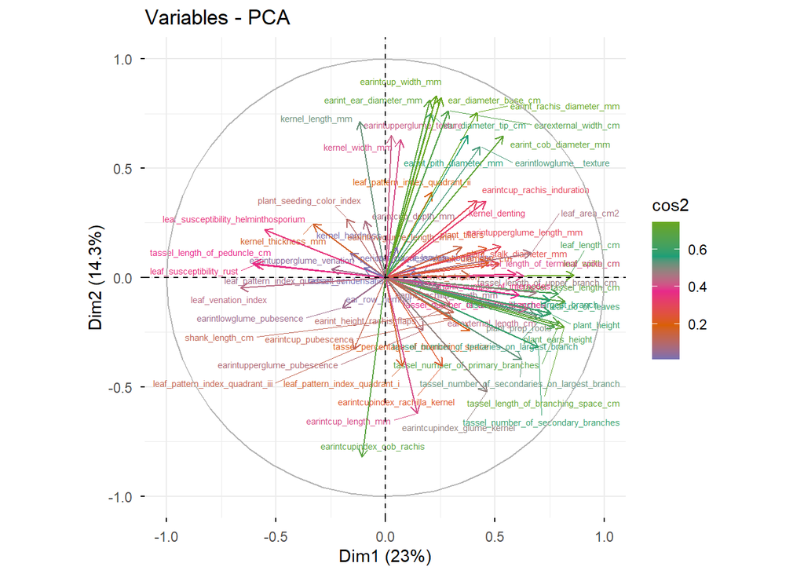

```r
var <- fviz_pca_var(mv, col.var = "cos2",
             gradient.cols = c("#7570b3", "#d95f02", "#e7298a", "#1b9e77", "#66a61e"),
             repel = TRUE,
             labelsize = 2)

var
```

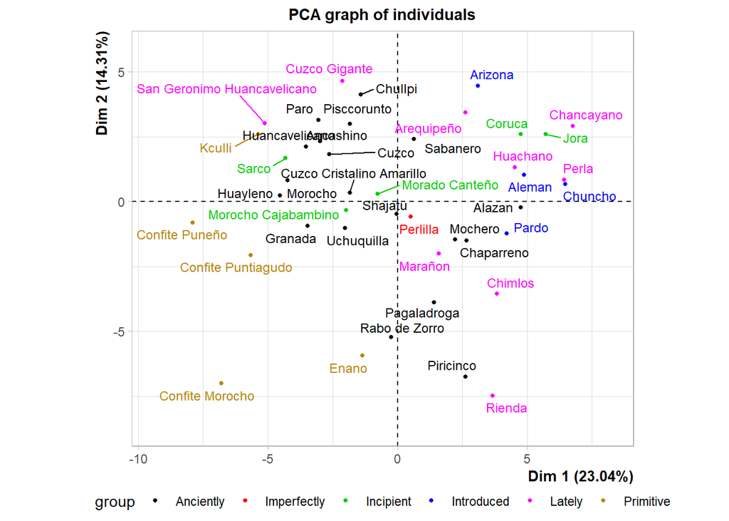

```r
ind <- plot.PCA(mv, choix = c("ind")
                , cex = 0.8
                , label = "ind"
                , invisible = "quali"
                , habillage = 1
                )  +
  theme(
    legend.position = "bottom",       # leyenda abajo
    legend.direction = "horizontal"   # en una sola línea
  ) + guides(color = guide_legend(nrow = 1))

ind
```

[figure not shown]

```r
cls <- HCPC(mv, graph = F)

clsp <- \() {

  plot.HCPC(cls, choice = "map", nb.clust=-1, draw.tree = F)

}

cos2p <- ~ {

pcainfo$cos2[, 1:2] %>%
  corrplot(
    is.corr = F
    , method = "number",
    type = "full",

    # Texto
    tl.col = "black",
    tl.srt = 45,          # mejor legibilidad
    tl.cex = 0.6,         # etiquetas más visibles

    # Números
    number.cex = 0.5,     # mayor tamaño
    number.digits = 1,    # control de precisión

    # Barra de color
    cl.cex = 0.7,
    cl.pos = "r",
    cl.align = "r",
    cl.ratio = 4        # evita que la barra comprima la figura
  )

}

grid <- list(ind, clsp) %>%
  plot_grid(plotlist = ., ncol = 1) %>%
  plot_grid(., cos2p, ncol = 2, rel_widths = c(1.8, 1))

grid
```

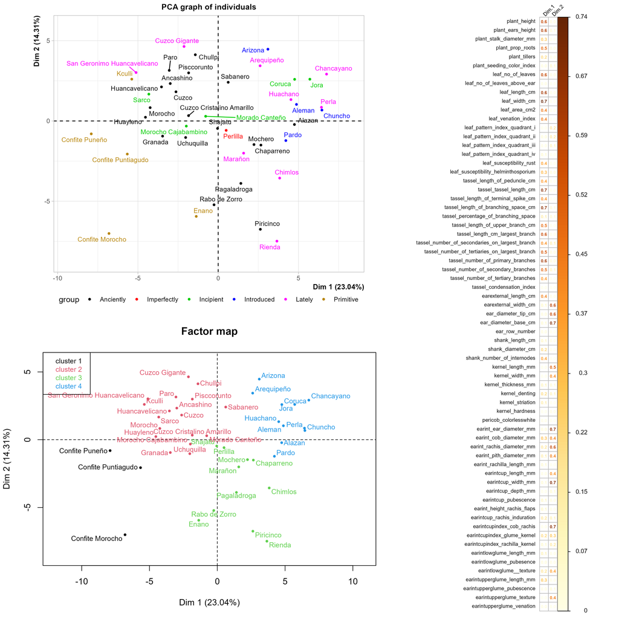

```r
plot <- grid %>%
  ggsave(plot = ., "manuscript/Figure-1.jpg", units = "cm"
                , width = 30, height = 30)

plot %>% include_graphics()
```

## 4.2 RO 2

> Excluir varibles que covarian?

```r
cos2_selvar <- pcainfo$cos2[, 1:2] %>%
  data.frame() %>%
  rownames_to_column(var = "variable") %>%
  filter(if_any(c(Dim.1, Dim.2), ~ . > 0.6))

cos2_selvar %>% write_sheet(ss = gs, sheet = "Table1")

cos2_selvar %>% kable(caption = "Selected variables with Cos2 > 0.6")
```

Selected variables with Cos2 > 0.6

| variable | Dim.1 | Dim.2 |
| --- | --- | --- |
| leaf_length_cm | 0.6253715 | 0.0056794 |
| leaf_width_cm | 0.7425418 | 0.0000972 |
| tassel_tassel_length_cm | 0.6722394 | 0.0119185 |
| tassel_length_of_branching_space_cm | 0.6669229 | 0.0510780 |
| tassel_number_of_primary_branches | 0.6286338 | 0.0445721 |
| ear_diameter_base_cm | 0.0649779 | 0.6771211 |
| earint_ear_diameter_mm | 0.0410824 | 0.6596875 |
| earintcup_width_mm | 0.0536532 | 0.6894338 |
| earintcupindex_cob_rachis | 0.0116738 | 0.6737550 |

```r
selvar <- cos2_selvar %>%
  dplyr::select(variable) %>%
  deframe()
```

```r
dtsl <- fb %>%
  dplyr::select(1, group, {{selvar}})

mv <- dtsl %>%
  column_to_rownames("race") %>%
  mutate(across(1, ~ as.factor(.))) %>%
  PCA(X = ., scale.unit = T, graph = F, quali.sup = c(1))

pcainfo <- factoextra::get_pca(mv); pcainfo
## Principal Component Analysis Results for variables
##  ===================================================
##   Name       Description
## 1 "$coord"   "Coordinates for the variables"
## 2 "$cor"     "Correlations between variables and dimensions"
## 3 "$cos2"    "Cos2 for the variables"
## 4 "$contrib" "contributions of the variables"

pcainfo$cor %>% kable(caption = "Variable correlations")
```

Variable correlations

|  | Dim.1 | Dim.2 | Dim.3 | Dim.4 | Dim.5 |
| --- | --- | --- | --- | --- | --- |
| leaf_length_cm | 0.8308622 | -0.2229874 | -0.0134729 | -0.3969653 | 0.1650893 |
| leaf_width_cm | 0.8764481 | -0.1870160 | -0.0155151 | -0.3076347 | 0.1211355 |
| tassel_tassel_length_cm | 0.7644579 | -0.3213711 | -0.3421325 | 0.3683335 | 0.0786417 |
| tassel_length_of_branching_space_cm | 0.8107652 | -0.4328769 | 0.0179191 | 0.3054413 | -0.0798985 |
| tassel_number_of_primary_branches | 0.7914000 | -0.3731171 | 0.3139275 | -0.0047146 | -0.3097609 |
| ear_diameter_base_cm | 0.4434870 | 0.7875535 | 0.3268558 | 0.1541004 | 0.0945557 |
| earint_ear_diameter_mm | 0.3986324 | 0.8191631 | 0.2809975 | 0.1187529 | 0.1369916 |
| earintcup_width_mm | 0.4158414 | 0.7564282 | -0.3900313 | 0.0276753 | 0.0659855 |
| earintcupindex_cob_rachis | -0.3123416 | -0.8027550 | 0.2286344 | 0.1704063 | 0.3762325 |

```r
pcainfo$contrib %>% kable(caption = "Variable Contribution")
```

Variable Contribution

|  | Dim.1 | Dim.2 | Dim.3 | Dim.4 | Dim.5 |
| --- | --- | --- | --- | --- | --- |
| leaf_length_cm | 17.465207 | 1.645138 | 0.0299268 | 28.7106823 | 8.410301 |
| leaf_width_cm | 19.434264 | 1.157176 | 0.0396871 | 17.2428416 | 4.528100 |
| tassel_tassel_length_cm | 14.785051 | 3.417081 | 19.2987230 | 24.7184188 | 1.908441 |
| tassel_length_of_branching_space_cm | 16.630521 | 6.199696 | 0.0529385 | 16.9978417 | 1.969928 |
| tassel_number_of_primary_branches | 15.845567 | 4.606085 | 16.2479490 | 0.0040497 | 29.609197 |
| ear_diameter_base_cm | 4.975967 | 20.521157 | 17.6137714 | 4.3265937 | 2.758983 |
| earint_ear_diameter_mm | 4.020321 | 22.201507 | 13.0180162 | 2.5693704 | 5.791108 |
| earintcup_width_mm | 4.374930 | 18.931153 | 25.0806560 | 0.1395476 | 1.343602 |
| earintcupindex_cob_rachis | 2.468172 | 21.321008 | 8.6183320 | 5.2906541 | 43.680340 |

```r
pcainfo$cos2 %>% kable(caption = "Variable Cos2")
```

Variable Cos2

|  | Dim.1 | Dim.2 | Dim.3 | Dim.4 | Dim.5 |
| --- | --- | --- | --- | --- | --- |
| leaf_length_cm | 0.6903321 | 0.0497234 | 0.0001815 | 0.1575815 | 0.0272545 |
| leaf_width_cm | 0.7681613 | 0.0349750 | 0.0002407 | 0.0946391 | 0.0146738 |
| tassel_tassel_length_cm | 0.5843959 | 0.1032794 | 0.1170546 | 0.1356695 | 0.0061845 |
| tassel_length_of_branching_space_cm | 0.6573402 | 0.1873824 | 0.0003211 | 0.0932944 | 0.0063838 |
| tassel_number_of_primary_branches | 0.6263140 | 0.1392164 | 0.0985505 | 0.0000222 | 0.0959518 |
| ear_diameter_base_cm | 0.1966807 | 0.6202406 | 0.1068347 | 0.0237469 | 0.0089408 |
| earint_ear_diameter_mm | 0.1589078 | 0.6710282 | 0.0789596 | 0.0141022 | 0.0187667 |
| earintcup_width_mm | 0.1729240 | 0.5721836 | 0.1521244 | 0.0007659 | 0.0043541 |
| earintcupindex_cob_rachis | 0.0975573 | 0.6444156 | 0.0522737 | 0.0290383 | 0.1415509 |

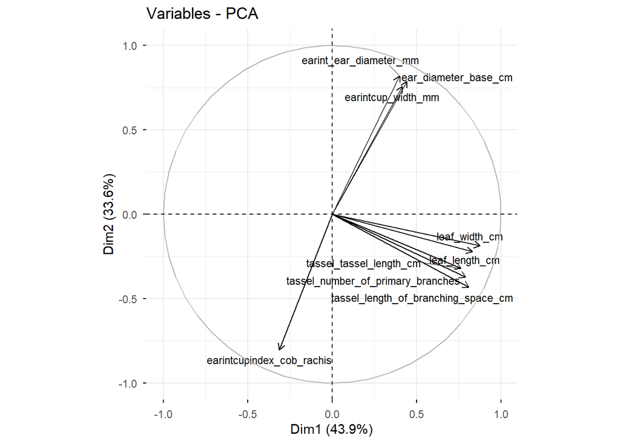

```r
var <- fviz_pca_var(mv
                    , repel = TRUE
                    , labelsize = 3
                    )

var
```

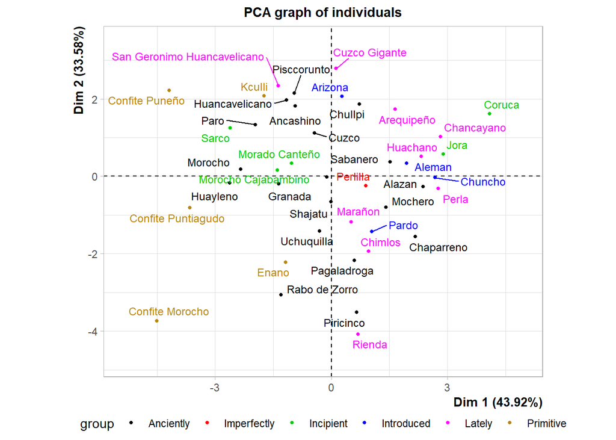

```r
ind <- plot.PCA(mv, choix = c("ind")
                , cex = 0.8
                , label = "ind"
                , invisible = "quali"
                , habillage = 1
                )  +
  theme(
    legend.position = "bottom",       # leyenda abajo
    legend.direction = "horizontal"   # en una sola línea
  ) + guides(color = guide_legend(nrow = 1))

ind
```

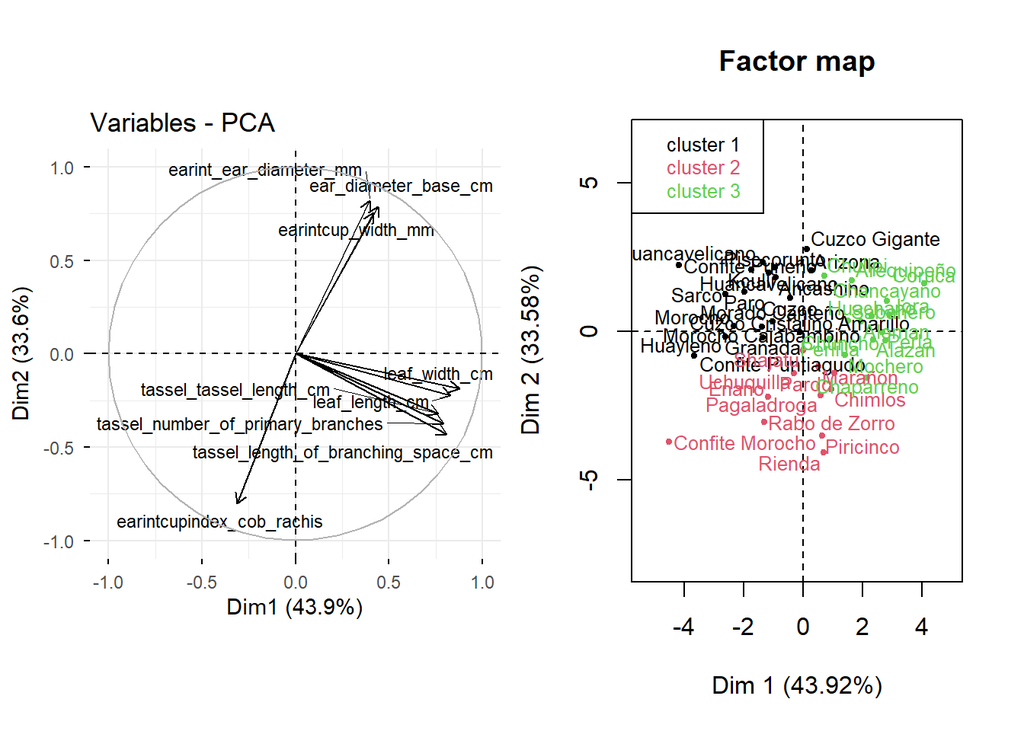

```r
cls <- HCPC(mv, graph = F)

clsp <- \() {

  plot.HCPC(cls, choice = "map", nb.clust=-1, draw.tree = F)

}

grid <- list(var, clsp) %>%
  plot_grid(plotlist = ., ncol = 2)

grid
```

```r
plot <- grid %>%
  ggsave(plot = ., "manuscript/Figure-2.jpg", units = "cm"
                , width = 30, height = 15)
```

## 4.3 RO 3

Comparar con la clasificación de Grobman et al. 1961 (Table 8, Pag. 139):

Grobman, Alexander; Wilfredo Salhuana, Ricardo Sevilla y Paul C. Mangelsdorf. 1961. Races of Maize in Peru: Their Origins, Evolution and Classification. (Publication 915). Washington, D.C.: National Academy of Sciences, National Research Council.

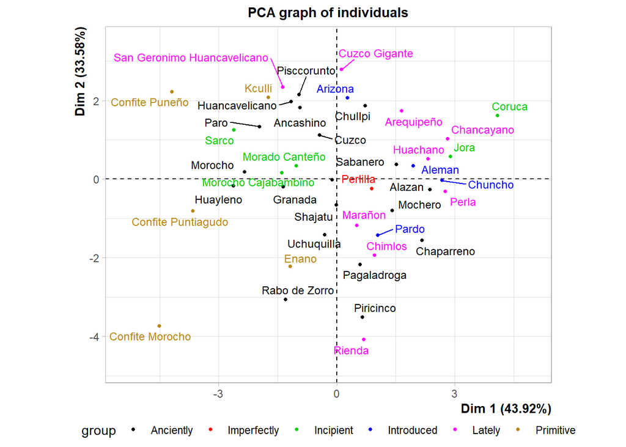

```r
ind <- plot.PCA(mv, choix = c("ind")
                , cex = 0.8
                , label = "ind"
                , invisible = "quali"
                , habillage = 1
                )  +
  theme(
    legend.position = "bottom",
    legend.direction = "horizontal"
  ) + guides(color = guide_legend(nrow = 1))




ind
```

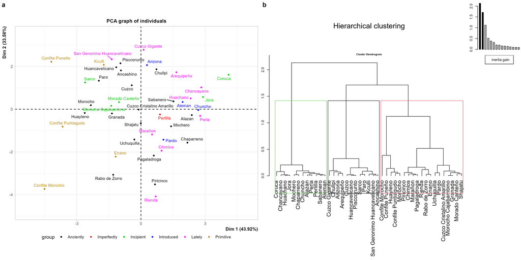

```r
# Phylogenic
phylo <- cls %>%
  fviz_dend(cex = 0.5
            , k_colors = "jco"
            , type = "circular"
            , repel = TRUE
            , phylo_layout = "layout.gem"
            , lwd = 0.1
            )

# rectangle
rect <- cls %>%
  fviz_dend(cex = 0.4
            , rect = TRUE
            , k_colors = "jco"
            , rect_border = "jco"
            , rect_fill = TRUE
            , horiz = TRUE
            , main = ""
            , lwd = 0.01
            )

clsp <- \() {

  plot.HCPC(cls, choice = "tree", nb.clust=-1, draw.tree = F, cex = 0.4)

}

plot <- list(ind, clsp) %>%
  plot_grid(plotlist = ., nrow = 1, labels = "auto") %>%
  ggsave2("manuscript/Figure-3.jpg"
          , plot = .
          , width =40 , height = 20, units = "cm")

plot %>% include_graphics()
```

# 5 References

Broman, K. W., & Woo, K. H. (2017). Data organization in spreadsheets. The American Statistician, 72(1), 2–10. https://doi.org/10.1080/00031305.2017.1375989

Zuur, A. F., Ieno, E. N., & Elphick, C. S. (2009). A protocol for data exploration to avoid common statistical problems. Methods in Ecology and Evolution, 1(1), 3–14. https://doi.org/10.1111/j.2041-210x.2009.00001.x

Francoishusson. (2017, July 13). PCA course using FactoMineR | R-bloggers. R-bloggers. https://www.r-bloggers.com/2017/07/pca-course-using-factominer/

Kozak, M., & Piepho, H. (2017). What’s normal anyway? Residual plots are more telling than significance tests when checking ANOVA assumptions. Journal of Agronomy and Crop Science, 204(1), 86–98. https://doi.org/10.1111/jac.12220

Tanaka, E., & Hui, F. K. C. (2019). Symbolic formulae for linear mixed models. In Communications in computer and information science (pp. 3–21). https://doi.org/10.1007/978-981-15-1960-4_1

Schielzeth, H., Dingemanse, N. J., Nakagawa, S., Westneat, D. F., Allegue, H., Teplitsky, C., Réale, D., Dochtermann, N. A., Garamszegi, L. Z., & Araya‐Ajoy, Y. G. (2020). Robustness of linear mixed‐effects models to violations of distributional assumptions. Methods in Ecology and Evolution, 11(9), 1141–1152. https://doi.org/10.1111/2041-210x.13434